# Risk Factor Analysis

## Outcome Variable

**Outcome Variable:** sstunted

## Predictor Variables

**Intervention Variable:** nchldlt5

**Adjustment Set:**

- arm
- W_mage
- meducyrs
- feducyrs
- hhwealth_quart
- hfoodsec
- W_mhtcm
- W_nrooms
- W_parity
- impfloor
- impsan
- safeh20
- delta_W_mage
- delta_meducyrs
- delta_feducyrs
- delta_hhwealth_quart
- delta_hfoodsec
- delta_W_mhtcm
- delta_W_nrooms
- delta_W_parity
- delta_impfloor
- delta_impsan
- delta_safeh20

## Stratifying Variables

The analysis was stratified on these variable(s):

- agecat
- studyid
- country

## Data Summary

| agecat | studyid | country | nchldlt5 | sstunted | n_cell | n |
| --- | --- | --- | --- | --- | --- | --- |
| Birth | ki1000108-IRC | INDIA | 1 | 0 | 79 | 388 |
| Birth | ki1000108-IRC | INDIA | 1 | 1 | 5 | 388 |
| Birth | ki1000108-IRC | INDIA | 2+ | 0 | 293 | 388 |
| Birth | ki1000108-IRC | INDIA | 2+ | 1 | 11 | 388 |
| Birth | ki1017093c-NIH-Crypto | BANGLADESH | 1 | 0 | 17 | 27 |
| Birth | ki1017093c-NIH-Crypto | BANGLADESH | 1 | 1 | 1 | 27 |
| Birth | ki1017093c-NIH-Crypto | BANGLADESH | 2+ | 0 | 9 | 27 |
| Birth | ki1017093c-NIH-Crypto | BANGLADESH | 2+ | 1 | 0 | 27 |
| Birth | kiGH5241-JiVitA-3 | BANGLADESH | 1 | 0 | 10646 | 19591 |
| Birth | kiGH5241-JiVitA-3 | BANGLADESH | 1 | 1 | 1458 | 19591 |
| Birth | kiGH5241-JiVitA-3 | BANGLADESH | 2+ | 0 | 6904 | 19591 |
| Birth | kiGH5241-JiVitA-3 | BANGLADESH | 2+ | 1 | 583 | 19591 |
| 6 months | ki1000108-IRC | INDIA | 1 | 0 | 78 | 407 |
| 6 months | ki1000108-IRC | INDIA | 1 | 1 | 11 | 407 |
| 6 months | ki1000108-IRC | INDIA | 2+ | 0 | 300 | 407 |
| 6 months | ki1000108-IRC | INDIA | 2+ | 1 | 18 | 407 |
| 6 months | ki1017093b-PROVIDE | BANGLADESH | 1 | 0 | 416 | 583 |
| 6 months | ki1017093b-PROVIDE | BANGLADESH | 1 | 1 | 10 | 583 |
| 6 months | ki1017093b-PROVIDE | BANGLADESH | 2+ | 0 | 153 | 583 |
| 6 months | ki1017093b-PROVIDE | BANGLADESH | 2+ | 1 | 4 | 583 |
| 6 months | ki1017093c-NIH-Crypto | BANGLADESH | 1 | 0 | 492 | 715 |
| 6 months | ki1017093c-NIH-Crypto | BANGLADESH | 1 | 1 | 15 | 715 |
| 6 months | ki1017093c-NIH-Crypto | BANGLADESH | 2+ | 0 | 200 | 715 |
| 6 months | ki1017093c-NIH-Crypto | BANGLADESH | 2+ | 1 | 8 | 715 |
| 6 months | ki1066203-TanzaniaChild2 | TANZANIA, UNITED REPUBLIC OF | 1 | 0 | 1384 | 2020 |
| 6 months | ki1066203-TanzaniaChild2 | TANZANIA, UNITED REPUBLIC OF | 1 | 1 | 7 | 2020 |
| 6 months | ki1066203-TanzaniaChild2 | TANZANIA, UNITED REPUBLIC OF | 2+ | 0 | 617 | 2020 |
| 6 months | ki1066203-TanzaniaChild2 | TANZANIA, UNITED REPUBLIC OF | 2+ | 1 | 12 | 2020 |
| 6 months | ki1148112-LCNI-5 | MALAWI | 1 | 0 | 362 | 811 |
| 6 months | ki1148112-LCNI-5 | MALAWI | 1 | 1 | 28 | 811 |
| 6 months | ki1148112-LCNI-5 | MALAWI | 2+ | 0 | 384 | 811 |
| 6 months | ki1148112-LCNI-5 | MALAWI | 2+ | 1 | 37 | 811 |
| 6 months | kiGH5241-JiVitA-3 | BANGLADESH | 1 | 0 | 10177 | 16800 |
| 6 months | kiGH5241-JiVitA-3 | BANGLADESH | 1 | 1 | 710 | 16800 |
| 6 months | kiGH5241-JiVitA-3 | BANGLADESH | 2+ | 0 | 5604 | 16800 |
| 6 months | kiGH5241-JiVitA-3 | BANGLADESH | 2+ | 1 | 309 | 16800 |
| 24 months | ki1000108-IRC | INDIA | 1 | 0 | 82 | 409 |
| 24 months | ki1000108-IRC | INDIA | 1 | 1 | 7 | 409 |
| 24 months | ki1000108-IRC | INDIA | 2+ | 0 | 286 | 409 |
| 24 months | ki1000108-IRC | INDIA | 2+ | 1 | 34 | 409 |
| 24 months | ki1017093b-PROVIDE | BANGLADESH | 1 | 0 | 390 | 577 |
| 24 months | ki1017093b-PROVIDE | BANGLADESH | 1 | 1 | 33 | 577 |
| 24 months | ki1017093b-PROVIDE | BANGLADESH | 2+ | 0 | 138 | 577 |
| 24 months | ki1017093b-PROVIDE | BANGLADESH | 2+ | 1 | 16 | 577 |
| 24 months | ki1017093c-NIH-Crypto | BANGLADESH | 1 | 0 | 336 | 514 |
| 24 months | ki1017093c-NIH-Crypto | BANGLADESH | 1 | 1 | 21 | 514 |
| 24 months | ki1017093c-NIH-Crypto | BANGLADESH | 2+ | 0 | 143 | 514 |
| 24 months | ki1017093c-NIH-Crypto | BANGLADESH | 2+ | 1 | 14 | 514 |
| 24 months | ki1066203-TanzaniaChild2 | TANZANIA, UNITED REPUBLIC OF | 1 | 0 | 4 | 6 |
| 24 months | ki1066203-TanzaniaChild2 | TANZANIA, UNITED REPUBLIC OF | 1 | 1 | 1 | 6 |
| 24 months | ki1066203-TanzaniaChild2 | TANZANIA, UNITED REPUBLIC OF | 2+ | 0 | 1 | 6 |
| 24 months | ki1066203-TanzaniaChild2 | TANZANIA, UNITED REPUBLIC OF | 2+ | 1 | 0 | 6 |
| 24 months | ki1148112-LCNI-5 | MALAWI | 1 | 0 | 257 | 571 |
| 24 months | ki1148112-LCNI-5 | MALAWI | 1 | 1 | 26 | 571 |
| 24 months | ki1148112-LCNI-5 | MALAWI | 2+ | 0 | 248 | 571 |
| 24 months | ki1148112-LCNI-5 | MALAWI | 2+ | 1 | 40 | 571 |
| 24 months | kiGH5241-JiVitA-3 | BANGLADESH | 1 | 0 | 4672 | 8622 |
| 24 months | kiGH5241-JiVitA-3 | BANGLADESH | 1 | 1 | 782 | 8622 |
| 24 months | kiGH5241-JiVitA-3 | BANGLADESH | 2+ | 0 | 2607 | 8622 |
| 24 months | kiGH5241-JiVitA-3 | BANGLADESH | 2+ | 1 | 561 | 8622 |

The following strata were considered:

- agecat: 24 months, studyid: ki1000108-IRC, country: INDIA
- agecat: 24 months, studyid: ki1017093b-PROVIDE, country: BANGLADESH
- agecat: 24 months, studyid: ki1017093c-NIH-Crypto, country: BANGLADESH
- agecat: 24 months, studyid: ki1066203-TanzaniaChild2, country: TANZANIA, UNITED REPUBLIC OF
- agecat: 24 months, studyid: ki1148112-LCNI-5, country: MALAWI
- agecat: 24 months, studyid: kiGH5241-JiVitA-3, country: BANGLADESH
- agecat: 6 months, studyid: ki1000108-IRC, country: INDIA
- agecat: 6 months, studyid: ki1017093b-PROVIDE, country: BANGLADESH
- agecat: 6 months, studyid: ki1017093c-NIH-Crypto, country: BANGLADESH
- agecat: 6 months, studyid: ki1066203-TanzaniaChild2, country: TANZANIA, UNITED REPUBLIC OF
- agecat: 6 months, studyid: ki1148112-LCNI-5, country: MALAWI
- agecat: 6 months, studyid: kiGH5241-JiVitA-3, country: BANGLADESH
- agecat: Birth, studyid: ki1000108-IRC, country: INDIA
- agecat: Birth, studyid: ki1017093c-NIH-Crypto, country: BANGLADESH
- agecat: Birth, studyid: kiGH5241-JiVitA-3, country: BANGLADESH

### Dropped Strata

Some strata were dropped due to rare outcomes:

- agecat: Birth, studyid: ki1017093c-NIH-Crypto, country: BANGLADESH
- agecat: 6 months, studyid: ki1017093b-PROVIDE, country: BANGLADESH
- agecat: 24 months, studyid: ki1066203-TanzaniaChild2, country: TANZANIA, UNITED REPUBLIC OF

## Methods Detail

We’re interested in the causal parameters $E[Y_a]$ for all values of $a \in \mathcal{A}$. These parameters represent the mean outcome if, possibly contrary to fact, we intervened to set all units to have $A=a$. Under the randomization and positivity assumptions, these are identified by the statistical parameters $\psi_a=E_W[E_{Y|A,W}(Y|A=a,W)]$. In addition, we’re interested in the mean of $Y$, $E[Y]$ under no intervention (the observed mean). We will estimate these parameters by using SuperLearner to fit the relevant likelihood factors – $E_{Y|A,W}(Y|A=a,W)$ and $p(A=a|W)$, and then updating our likelihood fit using a joint TMLE.

For unadjusted analyses ($W=\{\}$), initial likelihoods were estimated using Lrnr_glm to estimate the simple $E(Y|A)$ and Lrnr_mean to estimate $p(A)$. For adjusted analyses, a small library containing Lrnr_glmnet, Lrnr_xgboost, and Lrnr_mean was used.

Having estimated these parameters, we will then use the delta method to estimate relative risks and attributable risks relative to a prespecified baseline level of $A$.

# Results Detail

## Results Plots

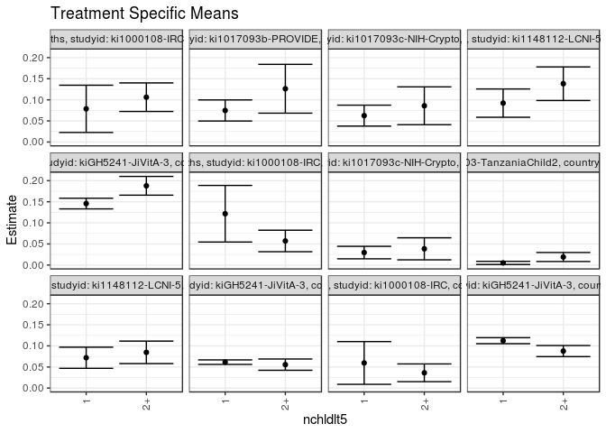

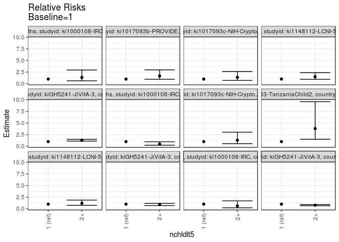

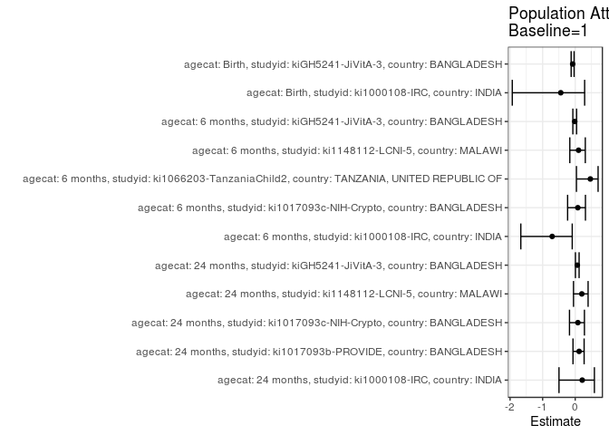

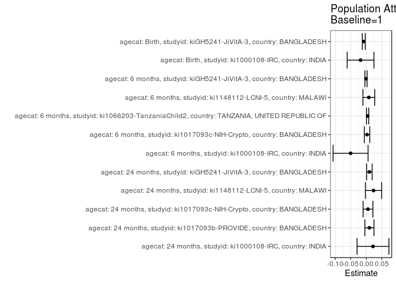

## Results Table

### Parameter: TSM

| agecat | studyid | country | intervention_level | baseline_level | estimate | ci_lower | ci_upper |
| --- | --- | --- | --- | --- | --- | --- | --- |
| Birth | ki1000108-IRC | INDIA | 1 | NA | 0.0595238 | 0.0088611 | 0.1101865 |
| Birth | ki1000108-IRC | INDIA | 2+ | NA | 0.0361842 | 0.0151644 | 0.0572040 |
| Birth | kiGH5241-JiVitA-3 | BANGLADESH | 1 | NA | 0.1123129 | 0.1051956 | 0.1194301 |
| Birth | kiGH5241-JiVitA-3 | BANGLADESH | 2+ | NA | 0.0877185 | 0.0745706 | 0.1008664 |
| 6 months | ki1000108-IRC | INDIA | 1 | NA | 0.1216482 | 0.0545695 | 0.1887268 |
| 6 months | ki1000108-IRC | INDIA | 2+ | NA | 0.0570887 | 0.0316177 | 0.0825598 |
| 6 months | ki1017093c-NIH-Crypto | BANGLADESH | 1 | NA | 0.0295858 | 0.0148264 | 0.0443452 |
| 6 months | ki1017093c-NIH-Crypto | BANGLADESH | 2+ | NA | 0.0384615 | 0.0123088 | 0.0646143 |
| 6 months | ki1066203-TanzaniaChild2 | TANZANIA, UNITED REPUBLIC OF | 1 | NA | 0.0050324 | 0.0013129 | 0.0087518 |
| 6 months | ki1066203-TanzaniaChild2 | TANZANIA, UNITED REPUBLIC OF | 2+ | NA | 0.0190779 | 0.0083846 | 0.0297712 |
| 6 months | ki1148112-LCNI-5 | MALAWI | 1 | NA | 0.0718940 | 0.0468370 | 0.0969510 |
| 6 months | ki1148112-LCNI-5 | MALAWI | 2+ | NA | 0.0846584 | 0.0579983 | 0.1113184 |
| 6 months | kiGH5241-JiVitA-3 | BANGLADESH | 1 | NA | 0.0614452 | 0.0560919 | 0.0667985 |
| 6 months | kiGH5241-JiVitA-3 | BANGLADESH | 2+ | NA | 0.0555296 | 0.0421749 | 0.0688844 |
| 24 months | ki1000108-IRC | INDIA | 1 | NA | 0.0786517 | 0.0226565 | 0.1346469 |
| 24 months | ki1000108-IRC | INDIA | 2+ | NA | 0.1062500 | 0.0724453 | 0.1400547 |
| 24 months | ki1017093b-PROVIDE | BANGLADESH | 1 | NA | 0.0747903 | 0.0497710 | 0.0998096 |
| 24 months | ki1017093b-PROVIDE | BANGLADESH | 2+ | NA | 0.1262422 | 0.0683950 | 0.1840895 |
| 24 months | ki1017093c-NIH-Crypto | BANGLADESH | 1 | NA | 0.0625195 | 0.0376796 | 0.0873595 |
| 24 months | ki1017093c-NIH-Crypto | BANGLADESH | 2+ | NA | 0.0858962 | 0.0410864 | 0.1307060 |
| 24 months | ki1148112-LCNI-5 | MALAWI | 1 | NA | 0.0921912 | 0.0586372 | 0.1257453 |
| 24 months | ki1148112-LCNI-5 | MALAWI | 2+ | NA | 0.1381849 | 0.0983750 | 0.1779949 |
| 24 months | kiGH5241-JiVitA-3 | BANGLADESH | 1 | NA | 0.1456863 | 0.1330836 | 0.1582890 |
| 24 months | kiGH5241-JiVitA-3 | BANGLADESH | 2+ | NA | 0.1878280 | 0.1655839 | 0.2100722 |

### Parameter: E(Y)

| agecat | studyid | country | intervention_level | baseline_level | estimate | ci_lower | ci_upper |
| --- | --- | --- | --- | --- | --- | --- | --- |
| Birth | ki1000108-IRC | INDIA | NA | NA | 0.0412371 | 0.0214268 | 0.0610475 |
| Birth | kiGH5241-JiVitA-3 | BANGLADESH | NA | NA | 0.1041805 | 0.0995043 | 0.1088567 |
| 6 months | ki1000108-IRC | INDIA | NA | NA | 0.0712531 | 0.0462303 | 0.0962759 |
| 6 months | ki1017093c-NIH-Crypto | BANGLADESH | NA | NA | 0.0321678 | 0.0192256 | 0.0451101 |
| 6 months | ki1066203-TanzaniaChild2 | TANZANIA, UNITED REPUBLIC OF | NA | NA | 0.0094059 | 0.0051955 | 0.0136164 |
| 6 months | ki1148112-LCNI-5 | MALAWI | NA | NA | 0.0801480 | 0.0614493 | 0.0988466 |
| 6 months | kiGH5241-JiVitA-3 | BANGLADESH | NA | NA | 0.0606548 | 0.0568002 | 0.0645093 |
| 24 months | ki1000108-IRC | INDIA | NA | NA | 0.1002445 | 0.0711031 | 0.1293859 |
| 24 months | ki1017093b-PROVIDE | BANGLADESH | NA | NA | 0.0849220 | 0.0621566 | 0.1076874 |
| 24 months | ki1017093c-NIH-Crypto | BANGLADESH | NA | NA | 0.0680934 | 0.0462948 | 0.0898920 |
| 24 months | ki1148112-LCNI-5 | MALAWI | NA | NA | 0.1155867 | 0.0893389 | 0.1418344 |
| 24 months | kiGH5241-JiVitA-3 | BANGLADESH | NA | NA | 0.1557643 | 0.1470293 | 0.1644993 |

### Parameter: RR

| agecat | studyid | country | intervention_level | baseline_level | estimate | ci_lower | ci_upper |
| --- | --- | --- | --- | --- | --- | --- | --- |
| Birth | ki1000108-IRC | INDIA | 1 | 1 | 1.0000000 | 1.0000000 | 1.0000000 |
| Birth | ki1000108-IRC | INDIA | 2+ | 1 | 0.6078947 | 0.2169190 | 1.7035666 |
| Birth | kiGH5241-JiVitA-3 | BANGLADESH | 1 | 1 | 1.0000000 | 1.0000000 | 1.0000000 |
| Birth | kiGH5241-JiVitA-3 | BANGLADESH | 2+ | 1 | 0.7810191 | 0.6629249 | 0.9201509 |
| 6 months | ki1000108-IRC | INDIA | 1 | 1 | 1.0000000 | 1.0000000 | 1.0000000 |
| 6 months | ki1000108-IRC | INDIA | 2+ | 1 | 0.4692939 | 0.2310271 | 0.9532940 |
| 6 months | ki1017093c-NIH-Crypto | BANGLADESH | 1 | 1 | 1.0000000 | 1.0000000 | 1.0000000 |
| 6 months | ki1017093c-NIH-Crypto | BANGLADESH | 2+ | 1 | 1.3000000 | 0.5593501 | 3.0213633 |
| 6 months | ki1066203-TanzaniaChild2 | TANZANIA, UNITED REPUBLIC OF | 1 | 1 | 1.0000000 | 1.0000000 | 1.0000000 |
| 6 months | ki1066203-TanzaniaChild2 | TANZANIA, UNITED REPUBLIC OF | 2+ | 1 | 3.7910516 | 1.4993541 | 9.5855087 |
| 6 months | ki1148112-LCNI-5 | MALAWI | 1 | 1 | 1.0000000 | 1.0000000 | 1.0000000 |
| 6 months | ki1148112-LCNI-5 | MALAWI | 2+ | 1 | 1.1775442 | 0.7384244 | 1.8777959 |
| 6 months | kiGH5241-JiVitA-3 | BANGLADESH | 1 | 1 | 1.0000000 | 1.0000000 | 1.0000000 |
| 6 months | kiGH5241-JiVitA-3 | BANGLADESH | 2+ | 1 | 0.9037258 | 0.7009139 | 1.1652222 |
| 24 months | ki1000108-IRC | INDIA | 1 | 1 | 1.0000000 | 1.0000000 | 1.0000000 |
| 24 months | ki1000108-IRC | INDIA | 2+ | 1 | 1.3508929 | 0.6193830 | 2.9463377 |
| 24 months | ki1017093b-PROVIDE | BANGLADESH | 1 | 1 | 1.0000000 | 1.0000000 | 1.0000000 |
| 24 months | ki1017093b-PROVIDE | BANGLADESH | 2+ | 1 | 1.6879495 | 0.9574610 | 2.9757592 |
| 24 months | ki1017093c-NIH-Crypto | BANGLADESH | 1 | 1 | 1.0000000 | 1.0000000 | 1.0000000 |
| 24 months | ki1017093c-NIH-Crypto | BANGLADESH | 2+ | 1 | 1.3739093 | 0.7179933 | 2.6290313 |
| 24 months | ki1148112-LCNI-5 | MALAWI | 1 | 1 | 1.0000000 | 1.0000000 | 1.0000000 |
| 24 months | ki1148112-LCNI-5 | MALAWI | 2+ | 1 | 1.4988944 | 0.9485696 | 2.3684972 |
| 24 months | kiGH5241-JiVitA-3 | BANGLADESH | 1 | 1 | 1.0000000 | 1.0000000 | 1.0000000 |
| 24 months | kiGH5241-JiVitA-3 | BANGLADESH | 2+ | 1 | 1.2892634 | 1.1146249 | 1.4912641 |

### Parameter: PAR

| agecat | studyid | country | intervention_level | baseline_level | estimate | ci_lower | ci_upper |
| --- | --- | --- | --- | --- | --- | --- | --- |
| Birth | ki1000108-IRC | INDIA | 1 | NA | -0.0182867 | -0.0612727 | 0.0246993 |
| Birth | kiGH5241-JiVitA-3 | BANGLADESH | 1 | NA | -0.0081324 | -0.0128971 | -0.0033676 |
| 6 months | ki1000108-IRC | INDIA | 1 | NA | -0.0503951 | -0.1065648 | 0.0057746 |
| 6 months | ki1017093c-NIH-Crypto | BANGLADESH | 1 | NA | 0.0025820 | -0.0061590 | 0.0113231 |
| 6 months | ki1066203-TanzaniaChild2 | TANZANIA, UNITED REPUBLIC OF | 1 | NA | 0.0043736 | 0.0008368 | 0.0079104 |
| 6 months | ki1148112-LCNI-5 | MALAWI | 1 | NA | 0.0082540 | -0.0107077 | 0.0272156 |
| 6 months | kiGH5241-JiVitA-3 | BANGLADESH | 1 | NA | -0.0007905 | -0.0042776 | 0.0026967 |
| 24 months | ki1000108-IRC | INDIA | 1 | NA | 0.0215928 | -0.0295941 | 0.0727798 |
| 24 months | ki1017093b-PROVIDE | BANGLADESH | 1 | NA | 0.0101317 | -0.0044642 | 0.0247277 |
| 24 months | ki1017093c-NIH-Crypto | BANGLADESH | 1 | NA | 0.0055738 | -0.0100550 | 0.0212027 |
| 24 months | ki1148112-LCNI-5 | MALAWI | 1 | NA | 0.0233955 | -0.0025688 | 0.0493597 |
| 24 months | kiGH5241-JiVitA-3 | BANGLADESH | 1 | NA | 0.0100780 | 0.0012976 | 0.0188584 |

### Parameter: PAF

| agecat | studyid | country | intervention_level | baseline_level | estimate | ci_lower | ci_upper |
| --- | --- | --- | --- | --- | --- | --- | --- |
| Birth | ki1000108-IRC | INDIA | 1 | NA | -0.4434524 | -1.9325479 | 0.2895070 |
| Birth | kiGH5241-JiVitA-3 | BANGLADESH | 1 | NA | -0.0780606 | -0.1244197 | -0.0336129 |
| 6 months | ki1000108-IRC | INDIA | 1 | NA | -0.7072691 | -1.6701853 | -0.0915976 |
| 6 months | ki1017093c-NIH-Crypto | BANGLADESH | 1 | NA | 0.0802676 | -0.2334419 | 0.3141892 |
| 6 months | ki1066203-TanzaniaChild2 | TANZANIA, UNITED REPUBLIC OF | 1 | NA | 0.4649816 | 0.0380762 | 0.7024248 |
| 6 months | ki1148112-LCNI-5 | MALAWI | 1 | NA | 0.1029841 | -0.1657273 | 0.3097550 |
| 6 months | kiGH5241-JiVitA-3 | BANGLADESH | 1 | NA | -0.0130320 | -0.0721393 | 0.0428167 |
| 24 months | ki1000108-IRC | INDIA | 1 | NA | 0.2154015 | -0.4980614 | 0.5890724 |
| 24 months | ki1017093b-PROVIDE | BANGLADESH | 1 | NA | 0.1193063 | -0.0679286 | 0.2737142 |
| 24 months | ki1017093c-NIH-Crypto | BANGLADESH | 1 | NA | 0.0818559 | -0.1757508 | 0.2830211 |
| 24 months | ki1148112-LCNI-5 | MALAWI | 1 | NA | 0.2024062 | -0.0526538 | 0.3956646 |
| 24 months | kiGH5241-JiVitA-3 | BANGLADESH | 1 | NA | 0.0647003 | 0.0063371 | 0.1196356 |